# Most common programming languages used in India ?

A data analysis using Stackoverflow’s 2018 and 2019 Annual Developer Survey.

[figure not shown]

## Introduction

With the advent of new areas in India such as Artificial Intelligence and Data Science, many programming languages that were poorly spoken and used are now experiencing a rise in popularity.

You may have already heard **“Python is the programming language of the moment”** or **“Functional Paradigm is much better than Object Oriented”**.

In this article, we are going to analyze real data to verify if these programming languages are really being used India or if they are just rumors.

For this, we are going to use data from Stackoverflow’s 2018 and 2019 Annual Developer Survey.

Every year, Stack Overflow conducts a massive survey of people on the site, covering all sorts of information like programming languages, jobs, code style and various other information.

[figure not shown]

Every year, Stack Overflow conducts a massive survey of people on it’s website, covering all sorts of information like programming languages, jobs, code style and more.

```python
# to handle datasets
import numpy as np
import pandas as pd
from collections import Counter

# to visualise al the columns in the dataframe
pd.pandas.set_option('display.max_columns', None)

# to make plots
import matplotlib.pyplot as plt
import seaborn as sns

import plotly.graph_objects as go

# to change plot style
sns.set(style="darkgrid")

# to ignore warnings
import warnings
warnings.filterwarnings("ignore")
```

```python
# Reading Stackoverflow survey data
df_2019 = pd.read_csv('developer_survey_2019/survey_results_public.csv')

df_2018 = pd.read_csv('developer_survey_2018/survey_results_public.csv')
```

```python
df_2018.head()
```

|  | Respondent | Hobby | OpenSource | Country | Student | Employment | FormalEducation | UndergradMajor | CompanySize | DevType | YearsCoding | YearsCodingProf | JobSatisfaction | CareerSatisfaction | HopeFiveYears | JobSearchStatus | LastNewJob | AssessJob1 | AssessJob2 | AssessJob3 | AssessJob4 | AssessJob5 | AssessJob6 | AssessJob7 | AssessJob8 | AssessJob9 | AssessJob10 | AssessBenefits1 | AssessBenefits2 | … |
| --- | --- | --- | --- | --- | --- | --- | --- | --- | --- | --- | --- | --- | --- | --- | --- | --- | --- | --- | --- | --- | --- | --- | --- | --- | --- | --- | --- | --- | --- | --- |
| 0 | 1 | Yes | No | Kenya | No | Employed part-time | Bachelor’s degree (BA, BS, B.Eng., etc.) | Mathematics or statistics | 20 to 99 employees | Full-stack developer | 3-5 years | 3-5 years | Extremely satisfied | Extremely satisfied | Working as a founder or co-founder of my own c... | I’m not actively looking, but I am open to new... | Less than a year ago | 10.0 | 7.0 | 8.0 | 1.0 | 2.0 | 5.0 | 3.0 | 4.0 | 9.0 | 6.0 | NaN | NaN | … |
| 1 | 3 | Yes | Yes | United Kingdom | No | Employed full-time | Bachelor’s degree (BA, BS, B.Eng., etc.) | A natural science (ex. biology, chemistry, phy... | 10,000 or more employees | Database administrator;DevOps specialist;Full-... | 30 or more years | 18-20 years | Moderately dissatisfied | Neither satisfied nor dissatisfied | Working in a different or more specialized tec... | I am actively looking for a job | More than 4 years ago | 1.0 | 7.0 | 10.0 | 8.0 | 2.0 | 5.0 | 4.0 | 3.0 | 6.0 | 9.0 | 1.0 | 5.0 | … |
| 2 | 4 | Yes | Yes | United States | No | Employed full-time | Associate degree | Computer science, computer engineering, or sof... | 20 to 99 employees | Engineering manager;Full-stack developer | 24-26 years | 6-8 years | Moderately satisfied | Moderately satisfied | Working as a founder or co-founder of my own c... | I’m not actively looking, but I am open to new... | Less than a year ago | NaN | NaN | NaN | NaN | NaN | NaN | NaN | NaN | NaN | NaN | NaN | NaN | … |
| 3 | 5 | No | No | United States | No | Employed full-time | Bachelor’s degree (BA, BS, B.Eng., etc.) | Computer science, computer engineering, or sof... | 100 to 499 employees | Full-stack developer | 18-20 years | 12-14 years | Neither satisfied nor dissatisfied | Slightly dissatisfied | Working as a founder or co-founder of my own c... | I’m not actively looking, but I am open to new... | Less than a year ago | NaN | NaN | NaN | NaN | NaN | NaN | NaN | NaN | NaN | NaN | NaN | NaN | … |
| 4 | 7 | Yes | No | South Africa | Yes, part-time | Employed full-time | Some college/university study without earning ... | Computer science, computer engineering, or sof... | 10,000 or more employees | Data or business analyst;Desktop or enterprise... | 6-8 years | 0-2 years | Slightly satisfied | Moderately satisfied | Working in a different or more specialized tec... | I’m not actively looking, but I am open to new... | Between 1 and 2 years ago | 8.0 | 5.0 | 7.0 | 1.0 | 2.0 | 6.0 | 4.0 | 3.0 | 10.0 | 9.0 | 1.0 | 10.0 | … |

```python
df_2019[df_2019.Country == 'India'].LanguageDesireNextYear
```

```
7        Bash/Shell/PowerShell;C;C++;Elixir;Erlang;Go;P...
9                     C#;Go;JavaScript;Kotlin;Python;R;SQL
14       Assembly;Bash/Shell/PowerShell;C;C++;C#;Go;HTM...
49                              HTML/CSS;JavaScript;Python
64                                                  Kotlin
                               ...
88808                                           Python;SQL
88825                                                  NaN
88852                                                  NaN
88853                             HTML/CSS;Java;JavaScript
88864                                           C++;Python
Name: LanguageDesireNextYear, Length: 9061, dtype: object
```

## 1. In India which Programming languages are most used to work and which programming languages are most required?

```python
print('2018 LanguageWorkedWith' , df_2018.LanguageWorkedWith.isna().sum())
print('2018 LanguageWorkedWith' , df_2018.LanguageDesireNextYear.isna().sum())
print('2019 LanguageWorkedWith' , df_2019.LanguageWorkedWith.isna().sum())
print('2019 LanguageWorkedWith' , df_2019.LanguageDesireNextYear.isna().sum())
```

```
2018 LanguageWorkedWith 20521
2018 LanguageWorkedWith 25611
2019 LanguageWorkedWith 1314
2019 LanguageWorkedWith 4795
```

```python
def filter_country(df, column_filter, country, columns):
    ''' Filter a dataframe by country.,
        returns filtred dataframe.
    '''
    df_copy = df.copy()

        ''' Dropping rows for this four column's df_2018 [ LanguageWorkedWith ,LanguageDesireNextYear ] &
            df_2019[LanguageWorkedWith,LanguageDesireNextYear]
            based on nan value because this column possess huge number of missing values '''

    for column in columns:
        df_copy = df_copy[df_copy[column_filter] == country].dropna(subset=[column])

    return df_copy

# Filter the dataframe by India and selecting some columns.
india_2018 = filter_country(df_2018, 'Country', 'India', ['LanguageWorkedWith', 'LanguageDesireNextYear'])
india_2019 = filter_country(df_2019, 'Country', 'India', ['LanguageWorkedWith', 'LanguageDesireNextYear'])
```

```python
def split_column(df, column):
    ''' Split column by ;,
        returns a splited series.
    '''

    df_copy = df.copy()
    column_series = df_copy[column].apply(lambda x: x.split(';'))

    return column_series

# Splitting the Data Frame by column into a Series.
worked_lang_2018 = split_column(india_2018, 'LanguageWorkedWith')
wanted_lang_2018 = split_column(india_2018, 'LanguageDesireNextYear')

worked_lang_2019 = split_column(india_2019, 'LanguageWorkedWith')
wanted_lang_2019 = split_column(india_2019, 'LanguageDesireNextYear')
```

```python
def disarray(array_list):
    ''' Flat a nested list,
        returns a flat list.
    '''

    objects = []

    for row in array_list:
        for obj in row:
            objects.append(obj.strip())

    return objects

# Flatting nested list objects.
list_worked_languages_2018 = disarray(worked_lang_2018)
list_wanted_languages_2018 = disarray(wanted_lang_2018)

list_worked_languages_2019 = disarray(worked_lang_2019)
list_wanted_languages_2019 = disarray(wanted_lang_2019)
```

```python
def group_list(data_list, year):
    ''' Group by count to a list,
        returns a result dict.
    '''

    grouped_list = dict(Counter(data_list))
    grouped_dict = [{'Programming Language':key, 'Count': value, 'Year': year} for key, value in grouped_list.items()]

    return grouped_dict

# Groping a list and creating a dict.
dict_worked_languages_2018 = group_list(list_worked_languages_2018, '2018')
dict_wanted_languages_2018 = group_list(list_wanted_languages_2018, '2018')

dict_worked_languages_2019 = group_list(list_worked_languages_2019, '2019')
dict_wanted_languages_2019 = group_list(list_wanted_languages_2019, '2019')
```

```python
def create_dataframe(data_dicts):
    ''' Create two dataframes and append them,
        returns a appended dataframe.
    '''

    df1 = pd.DataFrame(data_dicts[0])
    df2 = pd.DataFrame(data_dicts[1])

    df = df1.append(df2)

    return df

# Creating a Data Frame appending the data.
worked_languages = create_dataframe([dict_worked_languages_2018, dict_worked_languages_2019])
wanted_languages = create_dataframe([dict_wanted_languages_2018, dict_wanted_languages_2019])
```

```python
def percentage(df, column):
    ''' Scale data,
        returns data scaled.
    '''

    df_copy = df
    series = []

    for val in df_copy[column].unique():
        series.append(df_copy[df_copy[column] == val]['Count'] /
                      df_copy[df_copy[column] == val]['Count'].sum())

    joined_series = pd.Series()
    for i_series in series:
        joined_series = joined_series.append(i_series)

    return joined_series

# Calculating the percentage
worked_languages['Percentage'] = percentage(worked_languages, 'Year')
wanted_languages['Percentage'] = percentage(wanted_languages, 'Year')
```

```python
# Get the top 10 languages
top_10_worked_lang = worked_languages.sort_values(by=['Percentage'], ascending=False).head(10)['Programming Language'].unique()
top_10_wanted_lang = wanted_languages.sort_values(by=['Percentage'], ascending=False).head(10)['Programming Language'].unique()

worked_lang_chart = worked_languages[worked_languages['Programming Language'].isin(top_10_worked_lang)]
wanted_lang_chart = wanted_languages[wanted_languages['Programming Language'].isin(top_10_worked_lang)]
```

**Worked Languages** : We can see that : **Java Script**, **HTML/CSS**, **SQL** are still in the top positions. Stack Overflow 2018 survey data and Stack Overflow 2019 survey data

**Wanted Languages** : We can see that : **Java Script**, **Python**, **HTML/CSS** are still in the top positions. Stack Overflow 2018 survey data and Stack Overflow 2019 survey data

[figure not shown]

```python
# # Figure 1 — Percentage of use of programming languages among all the cited programming
# # languages by the respondents.
plt.figure(figsize=(14,8))
sns.barplot(x = 'Percentage',
            y = 'Programming Language',
            hue = 'Year',
            palette=sns.color_palette("Blues"),
            data = worked_lang_chart.sort_values(by='Percentage', ascending=False))

plt.xlabel("Percentage", fontsize = 14)
plt.ylabel("Programming Languages", fontsize = 14)
plt.legend(fontsize='x-large', title_fontsize='40')
plt.title('Most common Programming Languages used in India', size = 16)
plt.show()
```

## 2 Most wanted programming languages in India?

We can see that **Python** have grown tremendously close to other languages. This is probably happening because its’s a programming language that is very versatile and has been used extensively in data related areas.

Most of the programming languages that have appeared as programming languages most used at work, also appeared in the ranking of most wanted programming languages, this show us that are many people wanting to learn these languages.

[figure not shown]

```python
# Figure 2 — Percentage of desire of programming languages among all the cited programming
# languages by the respondents.



plt.figure(figsize=(14,8))
sns.barplot(x = 'Percentage',
            y = 'Programming Language',
            hue = 'Year',
            palette = sns.cubehelix_palette(8),
            data = wanted_lang_chart.sort_values(by='Percentage', ascending=False))

plt.title('Most wanted Programming Languages in India', size = 16)
plt.xlabel("Percentage", fontsize = 14)
plt.ylabel("Programming Languages", fontsize = 14)
plt.legend(fontsize='x-large', title_fontsize='40')
plt.show()
```

## 3 Downgrade popularity of Programming Languages in India from 2018 to 2019?

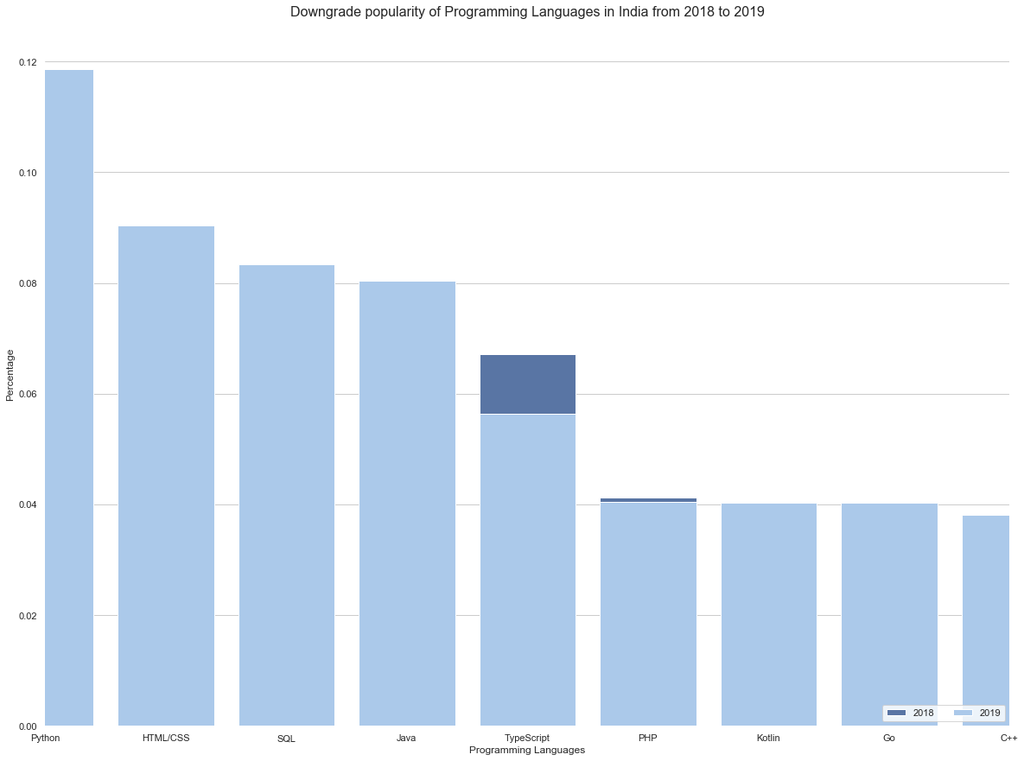

```python
# Load the example car crash dataset
wanted_languages_18 = wanted_languages[wanted_languages.Year == '2018'].sort_values(by='Percentage', ascending=False).head(10)
wanted_languages_19 = wanted_languages[wanted_languages.Year == '2019'].sort_values(by='Percentage', ascending=False).head(10)

# Initialize the matplotlib figure
f, ax = plt.subplots(figsize=(20, 15))


# Plot the total crashes
sns.set_color_codes("deep")
sns.barplot(x="Programming Language", y="Percentage", data=wanted_languages_18,
            label="2018", color="b")

# Plot the crashes where alcohol was involved
sns.set_color_codes("pastel")
sns.barplot(x="Programming Language", y="Percentage", data=wanted_languages_19,
            label="2019", color="b")

# Add a legend and informative axis label
ax.legend(ncol=2, loc="lower right", frameon=True)
ax.set(xlim=(1, 9), ylabel="Percentage", xlabel="Programming Languages")
plt.title('Downgrade popularity of Programming Languages in India from 2018 to 2019', size = 16)

sns.despine(left=True, bottom=True)
```

## 4 How does programming languages used at work relates with programming languages people want to learn?

By looking at the raw data, we can spot some patterns such as for people that use python at work, for example, python is also cited as language that those people wanted to learn in the next year.

A natural question arise:

**“The pattern observed for python holds for the other languages?”**

```python
# Grouping data to create a new dataframe

rows = []
for itens in list(zip(worked_lang_2018, wanted_lang_2018)):
    for i in itens[0]:
        rows.append({
            'Worked_PL': i,
            'Wanted_PL': Counter(itens[0])
        })

programming_language_transition = pd.DataFrame(rows).groupby('Worked_PL').agg({'Wanted_PL': 'sum'}).reset_index()
```

```python
# Creating a matrix

for row in programming_language_transition['Worked_PL']:
    programming_language_transition[row] = 0

for index, row in programming_language_transition.iterrows():
    total = sum([value for key, value in dict(row['Wanted_PL']).items()])
    for key, value in dict(row['Wanted_PL']).items():
         programming_language_transition[key].loc[index] = (value / total)
```

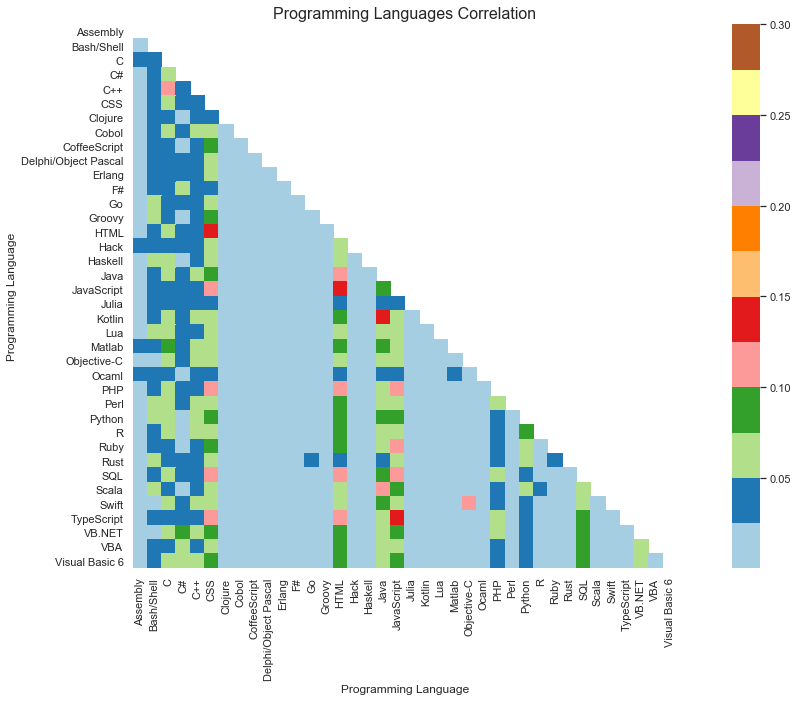

```python
## Figure 3 — Percentage of relationship of work programming languages and desire programming
## languages in 2018 and 2019.

corr = programming_language_transition.drop('Wanted_PL', axis=1).set_index('Worked_PL')
mask = np.zeros_like(corr)
mask[np.triu_indices_from(mask)] = True
with sns.axes_style("white"):
    f, ax = plt.subplots(figsize=(20, 10))
    plt.title('Programming Languages Correlation', size = 16)
    ax = sns.heatmap(corr, mask=mask,  cmap=sns.color_palette("Paired") ,vmax=.3, square=True)
    ax.set(xlabel='Programming Language', ylabel='Programming Language')
```

## Conclusion

In this article, we took a look at what were the most popular and most biased programming languages, according to Stackoverflow’s 2018 and 2019 Annual Developer Survey data.

## Reference

### [Stackoverflow Annual Developer Survey Data](https://insights.stackoverflow.com/survey)